# STA237A Hw11

Eric Kalosa-Kenyon

07 November 2017

Abstract

In this assignment, I address ARIMA models and model selection topics.

# ARIMA

## Invertibility

$|\theta |<1$ so $\Theta(z)$ has no zeros inside the unit circle. Hence, by theorem 3.1.2 (p86, Brockwell & Davis 2nd ed) this process is invertible. By invertibibity, we know there exists a set of coefficients $\Pi(z)$ such that
$$Z_t = \sum_{i=1}^\infty \pi_{t+1-i} X_{t+1-i} = \Pi(B)X_t$$
These coefficients $\Pi$ are determined by taking a power series around $z^\star=0$ of the ratio
$$\frac{\Phi(z)}{\Theta(z)} =
1 - (1+\theta)z + \theta(1+\theta)z^2 - \theta^2(1+\theta)z^3 +
\mathscr{O}(z^4)$$

## Truncated Forecast

Using the truncated forecast model
$$X_{n+1}^\star = (1-\theta)X_n + \theta X_n^\star
\quad\textrm{with}\quad
n\in\mathbb{N}$$
the following code loads some univariate time series observations, fits the preceeding ARIMA(0,1,1) model, and generates truncated forecasts from the model.

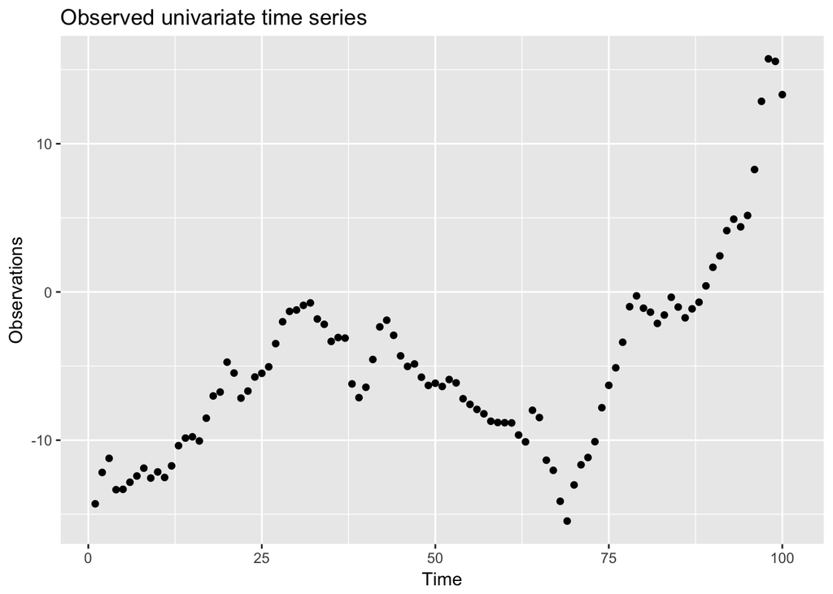

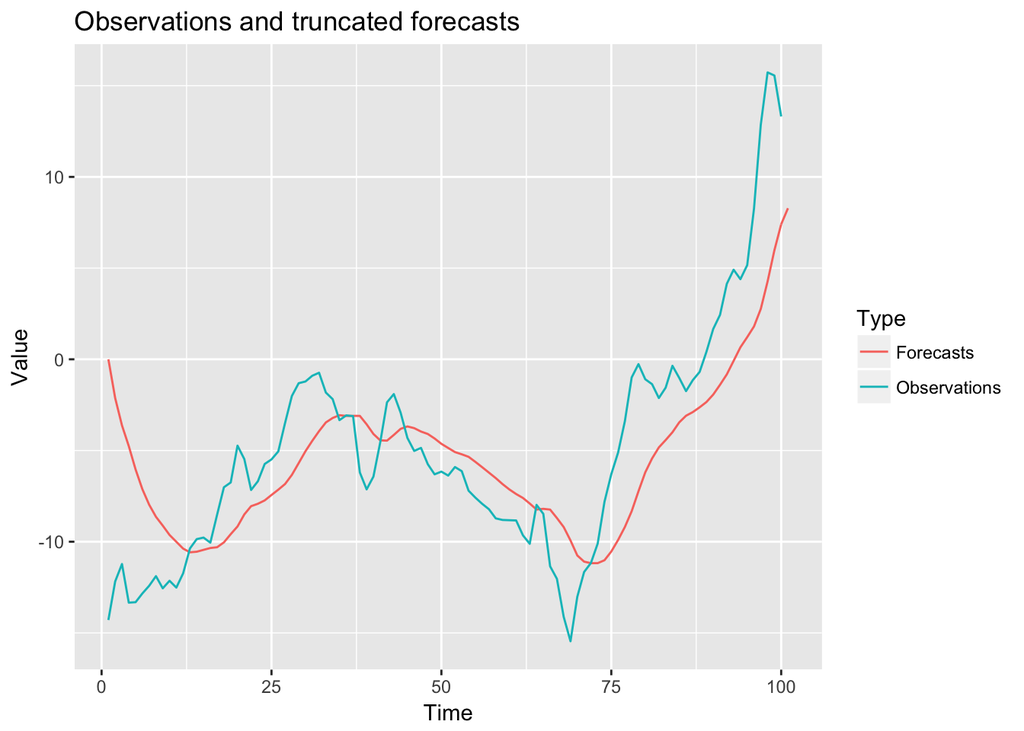

```r
rm(list=ls()) # clean up namespace

# Load external libraries
library(stats) # arima()
library(ggplot2) # fancy plotting
library(tidyr) # gather() for shaping dataframes

# Load data
df = read.table("arima011.txt")
colnames(df) = c("Observations")
n = dim(df)[1]
df[n+1,] = NA # extend df for forecasts computed later
rownames(df) = 1:(n+1)

# Fit ARIMA model
m = arima(df, c(0,1,1))
cs = coefficients(m)
theta = cs[[1]]

## Perform truncated forecasts based on the extracted ARIMA coefficient
xtrunc = function(xn, xtn, thet){
    # Truncated forecast function
    return((1-thet)*xn + thet*xtn)
}

x1t = 0
xts = matrix(NA, n+1, 1)
xts[1] = x1t
for(t in 1:n){
    xn = df$Observations[t]
    xnt = xts[t]
    xnp1t = xtrunc(xn, xnt, theta)
    xts[t+1] = xnp1t
}

df$Forecasts = xts
df$Time = 1:(n+1)

# Plot the observations
plt.obs = ggplot(df) + geom_point(aes(x=Time, y=Observations)) +
    labs(title="Observed univariate time series")

## Plot results on top of each other
df.p = df %>% gather("Type", "Value", c("Observations", "Forecasts"))
colnames(df.p) = c("Time", "Type", "Value")
plt.forecasts = ggplot(data=df.p) +
    geom_line(aes(x=Time, y=Value, color=Type)) +
    labs(title="Observations and truncated forecasts")
```

The forecasts are initially biased because $X_1^\star=0$, but the bias quickly relaxes. The truncated forecasts are less erratic than the observations, but the forecasts track the rough trend of the observations well in this case.